# The Problem

In healthcare systems, it is common that patients may not show up for their appointments, causing waste of resources and unnecessary waiting times for other patients.

- Can we predict if a patient will show up?

[figure not shown]

# The dataset

We will use a dataset containing patients' apppointment records at a hospital. We will first import the dataset.

```python
import pandas as pd
appts = pd.read_csv("Data/appointments.csv")
appts.head()
```

|  | PatientId | AppointmentID | Gender | AppointmentDay | AppointmentDOW | LeadTime | Age | Scholarship | Hipertension | Diabetes | Alcoholism | Handcap | SMS_received | No-show |
| --- | --- | --- | --- | --- | --- | --- | --- | --- | --- | --- | --- | --- | --- | --- |
| 0 | 2.759570e+13 | 5756417 | F | 2016-06-01 00:00:00+00:00 | Wednesday | 0 | 20 | 0 | 0 | 0 | 0 | 0 | 1 | No |
| 1 | 9.673194e+14 | 5523159 | F | 2016-05-03 00:00:00+00:00 | Tuesday | 35 | 37 | 0 | 0 | 0 | 0 | 0 | 0 | No |
| 2 | 3.951640e+12 | 5693080 | F | 2016-05-20 00:00:00+00:00 | Friday | 8 | 38 | 0 | 0 | 0 | 0 | 0 | 1 | Yes |
| 3 | 9.173245e+14 | 5654129 | F | 2016-06-03 00:00:00+00:00 | Friday | 31 | 24 | 0 | 0 | 0 | 0 | 0 | 0 | Yes |
| 4 | 3.995370e+12 | 5641070 | F | 2016-04-29 00:00:00+00:00 | Friday | 0 | 41 | 0 | 0 | 0 | 0 | 0 | 1 | No |

Target variable $y$: **No-show**: 'Yes' means a no-show (positive), 'No' means a show (negative)

- The problem is therefore a (binary) classification problem

Features ($X$):

One should check for missing values, duplications, outliers/anomolies, etc.

Let's examine the target variable to find how many **Yes**'s and **No**'s there are.

```python
appts['No-show'].value_counts()
```

```
No-show
No     860
Yes    245
Name: count, dtype: int64
```

**Question**: What may be a possible challenge for the classification problem?

The dataset is unbalanced!

- Many more **No**'s than **Yes**'s
- If we simply predict that **any** patient will show up (i.e., **No** no-show), then we will have a relatively good accuracy.

# Dealing with unbalanced dataset

What should we do?

- **Under-sampling**
  - Select and include a subset of records of the majority class, so that we have about the same number of majority-class recods and minority-class records.

[figure not shown]

- **Over-sampling**
  - Increase the number of records of the minority class, by doing **sampling with replacements**.

[figure not shown]

Use **under-sampling** when:

- You have a large dataset, and removing some samples will not cause a significant loss of information.
- You want to speed up training and reduce memory consumption.

Use **over-sampling** when:

- Your dataset is small, and removing majority class samples would significantly reduce information.
- You want to avoid discarding any data points.
- You have enough computational resources to handle the increased dataset size.

One can also do "hybrid-sampling". How?

Now let's seperate the no-shows from the shows.

```python
appts_no_show = appts[appts['No-show']=='Yes']
appts_show = appts[appts['No-show']=='No']
```

Then, we will use the function `df.sample()` to draw records (rows) from a DataFrame

- Use the keyword argument `n=` to specify the number of records to draw
- Use `replace=True` to allow duplications (necessary for over-sample)
- Use `random_state=` to ensure reproducibility

```python
no_of_show = len(appts_show)
appts_no_show_os = appts_no_show.sample(n=no_of_show,replace=True,random_state=42)
appts_no_show_os.shape
```

```
(860, 14)
```

Now combine the two parts back together.

- We will use `pd.concat()` to concatenate the two DataFrames containing no-shows and shows.
- by default, it vertically concatenates the DataFrames; Use `axis=1` if need to do horizontal concat

[figure not shown]

```python
appts = pd.concat([appts_no_show_os,appts_show])
appts['No-show'].value_counts()
```

```
No-show
Yes    860
No     860
Name: count, dtype: int64
```

```python
appts.reset_index(drop=True,inplace=True)
appts.head()
```

|  | PatientId | AppointmentID | Gender | AppointmentDay | AppointmentDOW | LeadTime | Age | Scholarship | Hipertension | Diabetes | Alcoholism | Handcap | SMS_received | No-show |
| --- | --- | --- | --- | --- | --- | --- | --- | --- | --- | --- | --- | --- | --- | --- |
| 0 | 9.694167e+14 | 5686132 | F | 2016-06-06 00:00:00+00:00 | Monday | 26 | 17 | 0 | 0 | 0 | 0 | 0 | 0 | Yes |
| 1 | 1.122440e+12 | 5697976 | M | 2016-05-19 00:00:00+00:00 | Thursday | 3 | 66 | 0 | 1 | 1 | 0 | 0 | 1 | Yes |
| 2 | 2.273480e+13 | 5565628 | F | 2016-05-02 00:00:00+00:00 | Monday | 21 | 23 | 0 | 0 | 0 | 0 | 0 | 0 | Yes |
| 3 | 3.679249e+14 | 5675275 | F | 2016-05-20 00:00:00+00:00 | Friday | 11 | 29 | 0 | 0 | 0 | 0 | 0 | 1 | Yes |
| 4 | 1.789380e+13 | 5643321 | M | 2016-05-09 00:00:00+00:00 | Monday | 7 | 38 | 0 | 0 | 0 | 0 | 0 | 1 | Yes |

# Feature Scaling

### What is feature scaling?

A technique used to standardize or normalize the range of independent variables (features) in a dataset.

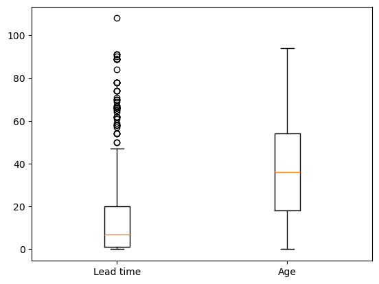

```python
import matplotlib.pyplot as plt
plt.boxplot([appts['LeadTime'],appts['Age']])
plt.xticks([1,2],['Lead time','Age'])
plt.show()
```

We will perform **standard scaling** of the features.

For example, consider the **Age** column.

- Its mean is **36**, and the standard dev. is **22**.

[figure not shown]

### Why scaling the features?

- For models like linear regression and logistic regressions, scaling helps in achieving faster and more stable convergence when training the models.
- For distance-based models like K-Nearest Neighbors (KNN), features with larger scales can disproportionately influence these distances, leading to biased results.

### How to scale features?

To implement the standard scaler, we need to import the `StandardScaler` from `sklearn`. Then, we need to:

1. Create the scaler
2. Fit it to the **feature** data: This computes the mean and standard deviation for each feature in the dataset.
3. Transform the data: This scales the **feature** data

We will only scale `LeadTime` and `Age` (why?).

```python
features_to_scale=['LeadTime','Age']
```

```python
from sklearn.preprocessing import StandardScaler

# 1. Create the scaler
scaler = StandardScaler()

# 2. Fit the scaler to data
scaler.fit(appts[features_to_scale])

# 3. Transform the data (both train & test)
scaled_features = scaler.transform(appts[features_to_scale])

appts[features_to_scale]=scaled_features

appts.head()
```

|  | PatientId | AppointmentID | Gender | AppointmentDay | AppointmentDOW | LeadTime | Age | Scholarship | Hipertension | Diabetes | Alcoholism | Handcap | SMS_received | No-show |
| --- | --- | --- | --- | --- | --- | --- | --- | --- | --- | --- | --- | --- | --- | --- |
| 0 | 9.694167e+14 | 5686132 | F | 2016-06-06 00:00:00+00:00 | Monday | 0.800406 | -0.876513 | 0 | 0 | 0 | 0 | 0 | 0 | Yes |
| 1 | 1.122440e+12 | 5697976 | M | 2016-05-19 00:00:00+00:00 | Thursday | -0.605823 | 1.269384 | 0 | 1 | 1 | 0 | 0 | 1 | Yes |
| 2 | 2.273480e+13 | 5565628 | F | 2016-05-02 00:00:00+00:00 | Monday | 0.494704 | -0.613750 | 0 | 0 | 0 | 0 | 0 | 0 | Yes |
| 3 | 3.679249e+14 | 5675275 | F | 2016-05-20 00:00:00+00:00 | Friday | -0.116700 | -0.350987 | 0 | 0 | 0 | 0 | 0 | 1 | Yes |
| 4 | 1.789380e+13 | 5643321 | M | 2016-05-09 00:00:00+00:00 | Monday | -0.361262 | 0.043157 | 0 | 0 | 0 | 0 | 0 | 1 | Yes |

Let's visualize the two variables again.

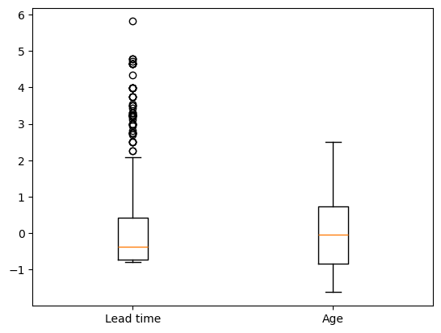

```python
import matplotlib.pyplot as plt
plt.boxplot([appts['LeadTime'],appts['Age']])
plt.xticks([1,2],['Lead time','Age'])
plt.show()
```

# One-hot encoding

First, let's convert the `No-show` value to binary values.

```python
appts['No-show']=appts['No-show'].map({'Yes':1,'No':0})
```

We will do **one-hot encoding** by creating dummy variables.

```python
appts_encoded = pd.get_dummies(appts,columns=['Gender','AppointmentDOW'],drop_first=True,dtype=int)
appts_encoded.head()
```

|  | PatientId | AppointmentID | AppointmentDay | LeadTime | Age | Scholarship | Hipertension | Diabetes | Alcoholism | Handcap | SMS_received | No-show | Gender_M | AppointmentDOW_Monday | AppointmentDOW_Thursday | AppointmentDOW_Tuesday | AppointmentDOW_Wednesday |
| --- | --- | --- | --- | --- | --- | --- | --- | --- | --- | --- | --- | --- | --- | --- | --- | --- | --- |
| 0 | 9.694167e+14 | 5686132 | 2016-06-06 00:00:00+00:00 | 0.800406 | -0.876513 | 0 | 0 | 0 | 0 | 0 | 0 | 1 | 0 | 1 | 0 | 0 | 0 |
| 1 | 1.122440e+12 | 5697976 | 2016-05-19 00:00:00+00:00 | -0.605823 | 1.269384 | 0 | 1 | 1 | 0 | 0 | 1 | 1 | 1 | 0 | 1 | 0 | 0 |
| 2 | 2.273480e+13 | 5565628 | 2016-05-02 00:00:00+00:00 | 0.494704 | -0.613750 | 0 | 0 | 0 | 0 | 0 | 0 | 1 | 0 | 1 | 0 | 0 | 0 |
| 3 | 3.679249e+14 | 5675275 | 2016-05-20 00:00:00+00:00 | -0.116700 | -0.350987 | 0 | 0 | 0 | 0 | 0 | 1 | 1 | 0 | 0 | 0 | 0 | 0 |
| 4 | 1.789380e+13 | 5643321 | 2016-05-09 00:00:00+00:00 | -0.361262 | 0.043157 | 0 | 0 | 0 | 0 | 0 | 1 | 1 | 1 | 1 | 0 | 0 | 0 |

# The Logistic regression model

Recall the linear regression suppose that the target variable is a linear function of the predictors

- $f(x_1,\ldots,x_n)=b_0+b_1 x_1 +b_2 x_2 + \cdots + b_n x_n$, which is sometimes called the decision function

But it may not be ideal for predicting the class of a data point. Why?

We can use $f(x_1,\ldots,x_n)$ to model the **probability** of a patient with the features $x_1,\ldots,x_n$ being in **class 1**, i.e., a no-show.

$$\mathbb{P}(y=1)=\frac{e^{f(x_1,\ldots,x_n)}}{e^{f(x_1,\ldots,x_n)}+1}$$

To implement the logistic regression mode, let's define our features (predictors) and our target variables.

- Drop the target variable **No-show** along with **PatientId**, **AppointmentID** and **AppointmentDay** to form the feature data X.
- Use the **No-show** variable as the target data y.

```python
appts_encoded.tail()
```

|  | PatientId | AppointmentID | AppointmentDay | LeadTime | Age | Scholarship | Hipertension | Diabetes | Alcoholism | Handcap | SMS_received | No-show | Gender_M | AppointmentDOW_Monday | AppointmentDOW_Thursday | AppointmentDOW_Tuesday | AppointmentDOW_Wednesday |
| --- | --- | --- | --- | --- | --- | --- | --- | --- | --- | --- | --- | --- | --- | --- | --- | --- | --- |
| 1715 | 1.439200e+12 | 5714991 | 2016-05-20 00:00:00+00:00 | -0.666964 | 0.962828 | 0 | 0 | 0 | 0 | 0 | 1 | 0 | 1 | 0 | 0 | 0 | 0 |
| 1716 | 3.797960e+11 | 5715367 | 2016-05-18 00:00:00+00:00 | -0.789244 | -1.577214 | 0 | 0 | 0 | 0 | 0 | 1 | 0 | 0 | 0 | 0 | 0 | 1 |
| 1717 | 5.239758e+14 | 5787029 | 2016-06-08 00:00:00+00:00 | -0.789244 | -0.613750 | 0 | 0 | 0 | 0 | 0 | 1 | 0 | 0 | 0 | 0 | 0 | 1 |
| 1718 | 9.928970e+13 | 5589666 | 2016-05-05 00:00:00+00:00 | 0.433564 | -1.358245 | 0 | 0 | 0 | 0 | 0 | 0 | 0 | 1 | 0 | 1 | 0 | 0 |
| 1719 | 6.124760e+13 | 5709480 | 2016-05-25 00:00:00+00:00 | -0.300121 | 0.174539 | 0 | 1 | 1 | 0 | 0 | 1 | 0 | 0 | 0 | 0 | 0 | 1 |

```python
X = appts_encoded.drop(['No-show','PatientId','AppointmentID','AppointmentDay'],axis=1)
y = appts_encoded['No-show']
```

## Train-test split

We will split the scaled feature data and the target variable.

- Note that the `stratify=y` argument will retain the ratio of positive class to the negative class in the training dataset and testing dataset the same as the original data before splitting.

```python
from sklearn.model_selection import train_test_split

X_train,X_test,y_train,y_test = train_test_split(X,y,test_size=0.2,random_state=42,stratify=y)

y_test.value_counts()
```

```
No-show
1    172
0    172
Name: count, dtype: int64
```

Now we will create and fit a logistic regression model.

- We need to import the function `LogisticRegression()` from the module `linear_model` in `sklearn`.

```python
from sklearn.linear_model import LogisticRegression

model = LogisticRegression()
model.fit(X_train,y_train)
```

```
LogisticRegression()
```

## Prediction on new data

Recall that logistic regression predicts the **probability** of being in **class 1**.

We can use `model.predict_proba()` to make a probabilistic prediction

- The input argument can be a 2D-array or a DataFrame of new data records

Let's predict on the testing data.

```python
y_prob = model.predict_proba(X_test)
y_prob[0:5]
```

```
array([[0.57776891, 0.42223109],
       [0.63477164, 0.36522836],
       [0.34878285, 0.65121715],
       [0.52417093, 0.47582907],
       [0.53488446, 0.46511554]])
```

Each row has two probility values.

- They are the probabilities of being a class 0 (show) and a class 1 (no-show) patient, for the corresponding row in the testing dataset.

### How do we make binary classifications?

**Threshold-based** classification

- If the probability of being in class 1 (no-show) is above a certain **threshold**, then predict no-show
- Otherwise, predict show.

The function `model.predict()` provides the classification, with the default threshold **0.5**.

```python
y_pred=model.predict(X_test)
y_pred
```

```
array([0, 0, 1, 0, 0, 1, 1, 1, 1, 1, 1, 0, 0, 0, 0, 1, 1, 0, 1, 0, 0, 0,
       0, 0, 0, 1, 0, 1, 0, 0, 0, 0, 1, 0, 1, 0, 0, 1, 0, 0, 1, 0, 0, 1,
       0, 1, 0, 1, 1, 0, 0, 0, 0, 0, 0, 0, 0, 1, 1, 0, 1, 1, 0, 1, 1, 0,
       1, 1, 0, 0, 0, 0, 1, 1, 1, 1, 0, 0, 1, 0, 1, 1, 1, 0, 0, 0, 0, 0,
       0, 0, 0, 1, 0, 1, 1, 1, 1, 1, 0, 1, 1, 1, 0, 1, 1, 0, 1, 1, 0, 0,
       0, 0, 0, 0, 1, 1, 0, 1, 0, 1, 1, 0, 1, 0, 1, 0, 1, 0, 0, 0, 0, 0,
       1, 1, 1, 1, 0, 1, 0, 1, 0, 1, 1, 0, 0, 1, 1, 1, 1, 0, 0, 1, 1, 0,
       0, 1, 0, 0, 1, 0, 1, 0, 1, 0, 0, 0, 1, 1, 1, 1, 0, 0, 1, 0, 1, 0,
       1, 0, 1, 0, 1, 0, 1, 1, 1, 0, 0, 0, 1, 0, 0, 1, 0, 1, 1, 1, 0, 0,
       0, 1, 1, 1, 1, 0, 1, 0, 0, 1, 0, 0, 0, 0, 1, 1, 0, 0, 0, 0, 1, 1,
       1, 1, 0, 1, 1, 0, 1, 0, 0, 1, 1, 1, 1, 1, 0, 1, 1, 1, 0, 1, 0, 0,
       1, 1, 0, 0, 0, 1, 1, 1, 1, 1, 1, 0, 1, 0, 0, 0, 0, 0, 1, 1, 1, 1,
       0, 1, 0, 1, 1, 1, 0, 1, 1, 1, 0, 1, 1, 0, 1, 0, 1, 0, 0, 1, 1, 1,
       1, 1, 0, 1, 0, 1, 1, 0, 1, 1, 0, 1, 0, 0, 1, 0, 1, 1, 1, 1, 0, 1,
       1, 1, 0, 1, 0, 0, 1, 1, 1, 0, 1, 0, 0, 0, 1, 1, 1, 0, 1, 0, 1, 1,
       1, 0, 0, 0, 0, 0, 0, 1, 1, 0, 0, 1, 1, 0])
```

To use a customized threshold, we can do the following.

- Check if the probability of belonging to class 1 is above the threshild
  - If yes, then the predicted class is 1 (no show)
  - If no, then the predicted class is 0 (show)

```python
threshold = 0.6
y_pred_cust = (y_prob[:,1]>=threshold).astype(int)
y_pred_cust
```

```
array([0, 0, 1, 0, 0, 0, 0, 1, 1, 1, 0, 0, 0, 0, 0, 1, 0, 0, 1, 0, 0, 0,
       0, 0, 0, 0, 0, 0, 0, 0, 0, 0, 0, 0, 1, 0, 0, 0, 0, 0, 0, 0, 0, 0,
       0, 1, 0, 0, 1, 0, 0, 0, 0, 0, 0, 0, 0, 0, 0, 0, 0, 1, 0, 0, 1, 0,
       1, 0, 0, 0, 0, 0, 0, 1, 0, 1, 0, 0, 0, 0, 1, 0, 0, 0, 0, 0, 0, 0,
       0, 0, 0, 0, 0, 0, 1, 1, 0, 1, 0, 0, 0, 1, 0, 1, 1, 0, 1, 1, 0, 0,
       0, 0, 0, 0, 1, 0, 0, 0, 0, 1, 1, 0, 0, 0, 0, 0, 1, 0, 0, 0, 0, 0,
       0, 1, 0, 0, 0, 0, 0, 1, 0, 1, 0, 0, 0, 0, 0, 0, 0, 0, 0, 0, 1, 0,
       0, 0, 0, 0, 0, 0, 0, 0, 0, 0, 0, 0, 1, 0, 0, 1, 0, 0, 1, 0, 1, 0,
       1, 0, 0, 0, 1, 0, 1, 1, 1, 0, 0, 0, 0, 0, 0, 1, 0, 1, 0, 0, 0, 0,
       0, 1, 1, 1, 1, 0, 1, 0, 0, 0, 0, 0, 0, 0, 1, 1, 0, 0, 0, 0, 1, 0,
       1, 0, 0, 1, 1, 0, 1, 0, 0, 1, 0, 0, 1, 1, 0, 1, 1, 1, 0, 0, 0, 0,
       1, 1, 0, 0, 0, 0, 0, 1, 1, 1, 1, 0, 0, 0, 0, 0, 0, 0, 0, 0, 1, 1,
       0, 0, 0, 0, 0, 1, 0, 0, 0, 1, 0, 0, 0, 0, 1, 0, 1, 0, 0, 1, 1, 0,
       0, 1, 0, 1, 0, 0, 1, 0, 0, 1, 0, 0, 0, 0, 1, 0, 0, 1, 1, 0, 0, 1,
       0, 1, 0, 1, 0, 0, 0, 1, 0, 0, 1, 0, 0, 0, 1, 0, 1, 0, 1, 0, 1, 0,
       1, 0, 0, 0, 0, 0, 0, 0, 1, 0, 0, 1, 0, 0])
```

## Evaluation of the model

How to evaluate the fitted model's performance?

Performance metrics:

- The confusion matrix
- Metrics in the classification report
- The ROC curve

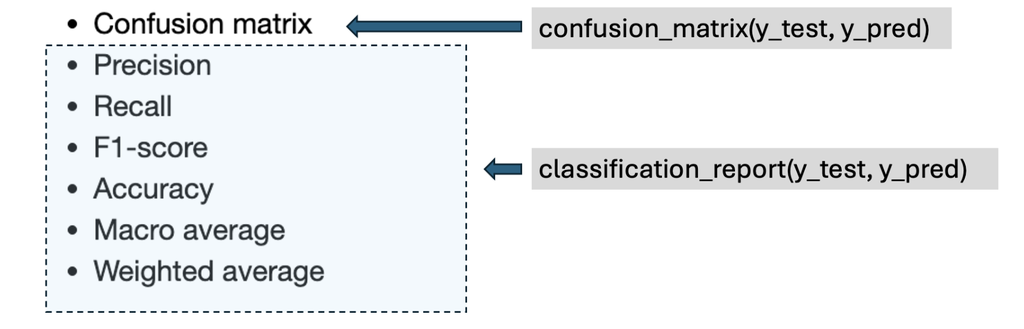

### The confusion matrix and the classification report

Let's import the methods `confusion_matrix` and `classification_report` to get the performance measures.

```python
from sklearn.metrics import confusion_matrix, classification_report
```

Get the confusion matrix.

```python
cm = confusion_matrix(y_test,y_pred)
print(cm)
```

```
[[116  56]
 [ 53 119]]
```

Get the classification report.

```python
cr = classification_report(y_test,y_pred)
print(cr)
```

```
              precision    recall  f1-score   support

           0       0.69      0.67      0.68       172
           1       0.68      0.69      0.69       172

    accuracy                           0.68       344
   macro avg       0.68      0.68      0.68       344
weighted avg       0.68      0.68      0.68       344
```

One may also get the scores individually.

```python
from sklearn.metrics import accuracy_score, precision_score, recall_score, f1_score

accuracy = accuracy_score(y_test, y_pred)
precision = precision_score(y_test, y_pred)
recall = recall_score(y_test, y_pred)
f1 = f1_score(y_test, y_pred)

print(f"Accuracy={accuracy:0.4f}, Precision={precision:0.4f}, Recall={recall:0.4f}, F1={f1:0.4f}")
```

```
Accuracy=0.6831, Precision=0.6800, Recall=0.6919, F1=0.6859
```

Refer to the lecture slides for interpretations of the performance measures.

## How does the features affect no-show (the target)?

Recall the decision function.

[figure not shown]

We can use the attributes `intercept_` and `coef_` of the model to get the intercept and coefficients of the fitted model.

Note that:

- Both end with an underscore
- `coef_` is a 2D-array with only one row.

```python
model.coef_[0]
```

```
array([ 0.47187276, -0.05975935,  0.11806616, -0.07418755, -0.39356528,
       -1.26181334, -1.32973645, -0.10998632,  0.00664656, -0.57428777,
       -0.24961798, -0.69150246, -0.84471778])
```

```python
df_coeff=pd.DataFrame({'Variable':X.columns,'Coeff':model.coef_[0]}).sort_values(by='Coeff')
df_coeff
```

|  | Variable | Coeff |
| --- | --- | --- |
| 6 | Handcap | -1.329736 |
| 5 | Alcoholism | -1.261813 |
| 12 | AppointmentDOW_Wednesday | -0.844718 |
| 11 | AppointmentDOW_Tuesday | -0.691502 |
| 9 | AppointmentDOW_Monday | -0.574288 |
| 4 | Diabetes | -0.393565 |
| 10 | AppointmentDOW_Thursday | -0.249618 |
| 7 | SMS_received | -0.109986 |
| 3 | Hipertension | -0.074188 |
| 1 | Age | -0.059759 |
| 8 | Gender_M | 0.006647 |
| 2 | Scholarship | 0.118066 |
| 0 | LeadTime | 0.471873 |

**Feature importance**:

- The coefficients measure by how much the decision function (and thus the probability of being in class 1) will change if the feature changes by 1 unit
- In the current example,
  - how do the features affect the outcome, and
  - which feature is more important/influential?

**Note**: Feature importance, the way it was defined here, relies on the unit of measure of each variable. It is important to note that the importance levels derived are only for the case where variables are in their current units of measure (because it involves the change in the value of the variable by one unit), and are not representing a general evaluation of features, regardless of their unit of measure.

### The ROC curve and the AUC score

The **receiver operating curve** plots:

- the True Positive Rate (Recall) on the y-axis, vs.
- the False Positive Rate on the x-axis,

for *various probability thresholds*.

To plot the ROC curve, we will use the function `roc_curve` in the `sklearn.metrics` module to get false positive rates (`fpr`) and false positive rates (`tpr`) for different values of thresholds.

- The input arguments to the `roc_curve` are:
  - `y_test`, and
  - the **probability of being in class 1** (no-show)

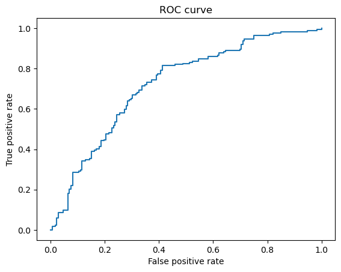

```python
from sklearn.metrics import roc_curve, roc_auc_score

import matplotlib.pyplot as plt

fpr,tpr,thresholds = roc_curve(y_test,y_prob[:,1])

plt.plot(fpr,tpr)
plt.xlabel('False positive rate')
plt.ylabel('True positive rate')
plt.title('ROC curve')
plt.show()
```

The **area under the curve** measures overall ability of the model to distinguish between classes

- The larger, the better performance of the model
- Being greater than 0.5 means that it is better than random guesses

We can use the `roc_auc_score` function in the `sklearn.metrics` module to get the AUC score.

- The input arguments are:
  - the observations in the test set (`y_test`)
  - the predicted probability of the positive class in the test set `y_prob[:,1]`

```python
auc_score = roc_auc_score(y_test,y_prob[:,1])
auc_score
```

```
0.7220118983234182
```

The definition of a "good" AUC score depends heavily on the specific domain or use case.

Rules of thumb:

- a score 0.5 is the same as a random guess
- a score of 0.7 or higher is often considered acceptable/adequate

# Feature selection

Many predictors are included in our model. With a relatively small sample, this may potentially cause the problem of **overfitting**.

The main idea for mitigating overfitting is to reduce the complexity of the model.

- For example, to use fewer features.

## Recursive Feature Elimination (RFE)

RFE is a feature selection method in `scikit-learn`

- It builds on top of a learning model.
- It recursively removing features and building a model on the remaining features.
- It ranks the features by importance and selects the top ones.

Example: Selecting 4 out of 6 features

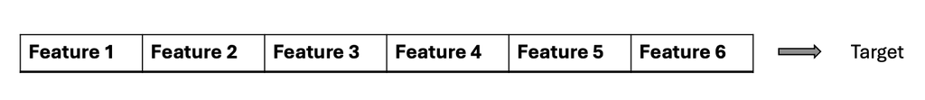

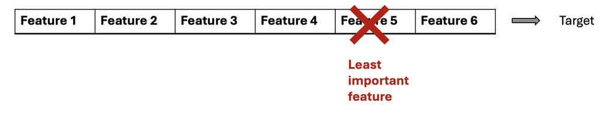

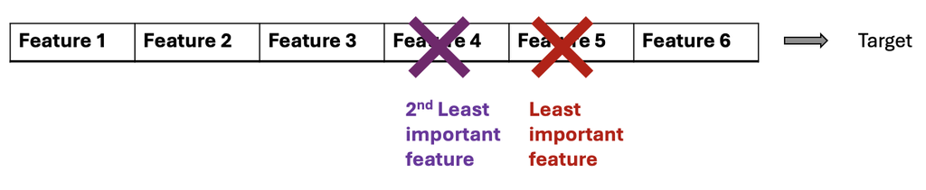

Let's use RFE to select variables.

```python
from sklearn.feature_selection import RFE
```

Build an RFE model

- use `estimator=` to build the RFE model on top of the learning model
- use `n_features_to_select=` to specify the number of features to include
- use `.fit()` method of the RFE model to fit it to the training data

```python
n_features = 10
rfe = RFE(estimator=model,n_features_to_select=n_features)
rfe.fit(X_train,y_train)
```

```
RFE(estimator=LogisticRegression(), n_features_to_select=10)
```

We can view which features are selected by the attribute `rfe.support_`

```python
X.columns[rfe.support_]
```

```
Index(['LeadTime', 'Scholarship', 'Hipertension', 'Diabetes', 'Alcoholism',
       'Handcap', 'AppointmentDOW_Monday', 'AppointmentDOW_Thursday',
       'AppointmentDOW_Tuesday', 'AppointmentDOW_Wednesday'],
      dtype='object')
```

Now let's make predictions on the test data based on the rfe model.

```python
y_pred_rfe = rfe.predict(X_test)
cm_rfe = confusion_matrix(y_test,y_pred_rfe)
cr_rfe = classification_report(y_test,y_pred_rfe)

print(cm_rfe)
print(cr_rfe)
```

```
[[118  54]
 [ 54 118]]
              precision    recall  f1-score   support

           0       0.69      0.69      0.69       172
           1       0.69      0.69      0.69       172

    accuracy                           0.69       344
   macro avg       0.69      0.69      0.69       344
weighted avg       0.69      0.69      0.69       344
```

The number of features to select is a **hyperparameter**, as opposed to model parameters.

- A hyperparameter is given to and not adjusted by the model.
- Hyperparameters can be "tuned" to improve testing performance.

In the following, we consider a list of potential values for the hyperparameter **number of features to select** and find the one with the highest accuracy.

```python
n_features_list = range(1,14)
accuracy_list = []
```

```python
for n_features in n_features_list:
    rfe = RFE(estimator=model,n_features_to_select=n_features)
    rfe.fit(X_train,y_train)
    y_pred_rfe = rfe.predict(X_test)

    accuracy = accuracy_score(y_test,y_pred_rfe)
    accuracy_list.append(accuracy)

accuracy_list
```

```
[0.49709302325581395,
 0.49709302325581395,
 0.5319767441860465,
 0.6511627906976745,
 0.6686046511627907,
 0.6947674418604651,
 0.6656976744186046,
 0.6773255813953488,
 0.6686046511627907,
 0.686046511627907,
 0.6802325581395349,
 0.6831395348837209,
 0.6831395348837209]
```

We may visualize accuracy vs. number of features.

To that end, we will plot `accuracy_list` vs. `n_features_list`.

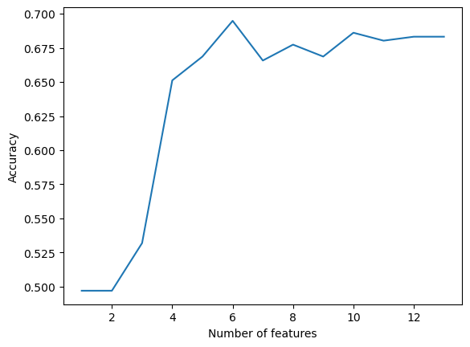

```python
import matplotlib.pyplot as plt
plt.plot(n_features_list,accuracy_list)
plt.xlabel('Number of features')
plt.ylabel('Accuracy')
plt.show()
```

Let us find the value of `n_features` corresponding to the highest accuracty.

Since `n_features_list` contains all the values of `n_features` we tried and the corresponding accuracies are included in `accuracy_list`, we can find the index of the maximum value in `accuracy_list`.

Below, we will:

1. use `np.argmax()` to find the *index* of the maximum accuracy value in `accuracy_list`;
2. use `n_features_list[index]` to find the number of features corresponding to the highest accuracy.

```python
import numpy as np

max_accu_idx = np.argmax(accuracy_list)
n_features = n_features_list[max_accu_idx]
n_features
```

```
6
```

Finally, we can repeat the training with `n_features=6`.

```python
rfe = RFE(estimator=model,n_features_to_select=6)
rfe.fit(X_train,y_train)

X.columns[rfe.support_]
```

```
Index(['LeadTime', 'Diabetes', 'Alcoholism', 'Handcap',
       'AppointmentDOW_Tuesday', 'AppointmentDOW_Wednesday'],
      dtype='object')
```

```python
selected_model = rfe.estimator_
pd.DataFrame({'variable':X.columns[rfe.support_],'coeffcicients':selected_model.coef_[0]})
```

|  | variable | coeffcicients |
| --- | --- | --- |
| 0 | LeadTime | 0.485371 |
| 1 | Diabetes | -0.591445 |
| 2 | Alcoholism | -1.260100 |
| 3 | Handcap | -1.373076 |
| 4 | AppointmentDOW_Tuesday | -0.439255 |
| 5 | AppointmentDOW_Wednesday | -0.581624 |

**Note**: There are many different parts to a logistic regression. For a review of other arguments please see [sklearn.linear_model.LogisticRegression — scikit-learn 0.24.2 documentation](https://scikit-learn.org/stable/modules/generated/sklearn.linear_model.LogisticRegression.html).